# pablo_project_1

Pablo

6/18/2022

# Course project Week 1

## Document that describes the project, including code

P1_1 Loading and preprocessing the data Show any code that is needed to Load the data (i.e. read.csv()) Process/transform the data (if necessary) into a format suitable for your analysis

```r
csv_data <- read.csv(file ='activity.csv')
csv_data$date <- as.Date(as.character(csv_data$date))
head(csv_data)
```

```
##   steps       date interval
## 1    NA 2012-10-01        0
## 2    NA 2012-10-01        5
## 3    NA 2012-10-01       10
## 4    NA 2012-10-01       15
## 5    NA 2012-10-01       20
## 6    NA 2012-10-01       25
```

P1_2 What is mean total number of steps taken per day? For this part of the assignment, you can ignore the missing values in the dataset. Calculate the total number of steps taken per day

```r
sum_steps <- aggregate(csv_data$steps, by=list(date=csv_data$date), FUN=sum, na.rm = TRUE)
head(sum_steps)
```

```
##         date     x
## 1 2012-10-01     0
## 2 2012-10-02   126
## 3 2012-10-03 11352
## 4 2012-10-04 12116
## 5 2012-10-05 13294
## 6 2012-10-06 15420
```

If you do not understand the difference between a histogram and a barplot, research the difference between them. Make a histogram of the total number of steps taken each day

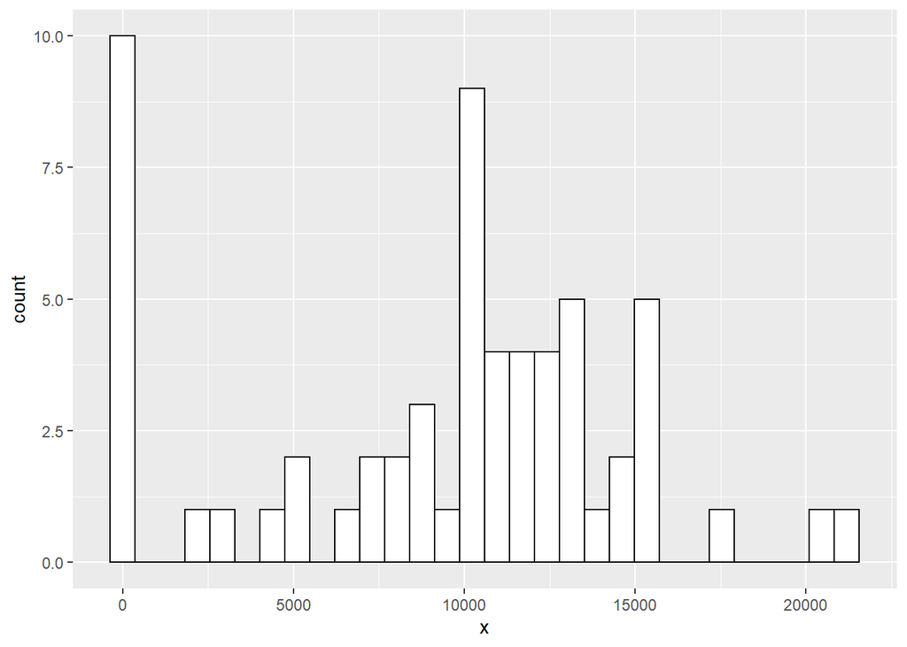

Calculate and report the mean and median of the total number of steps taken per day

```r
my_mean <- mean(sum_steps$x, na.rm = TRUE)
my_median <- median(sum_steps$x, na.rm = TRUE)
my_mean
```

```
## [1] 9354.23
```

```r
my_median
```

```
## [1] 10395
```

P1_3 What is the average daily activity pattern?

```r
interval_steps <- aggregate(csv_data$steps, by=list(interval=csv_data$interval), FUN=mean, na.rm = TRUE)
colnames(interval_steps)[colnames(interval_steps) == "x"] <- "nbr_steps"
```

Make a time series plot (i.e. type = “l”) of the 5-minute interval (x-axis) and the average number of steps taken, averaged across all days (y-axis)

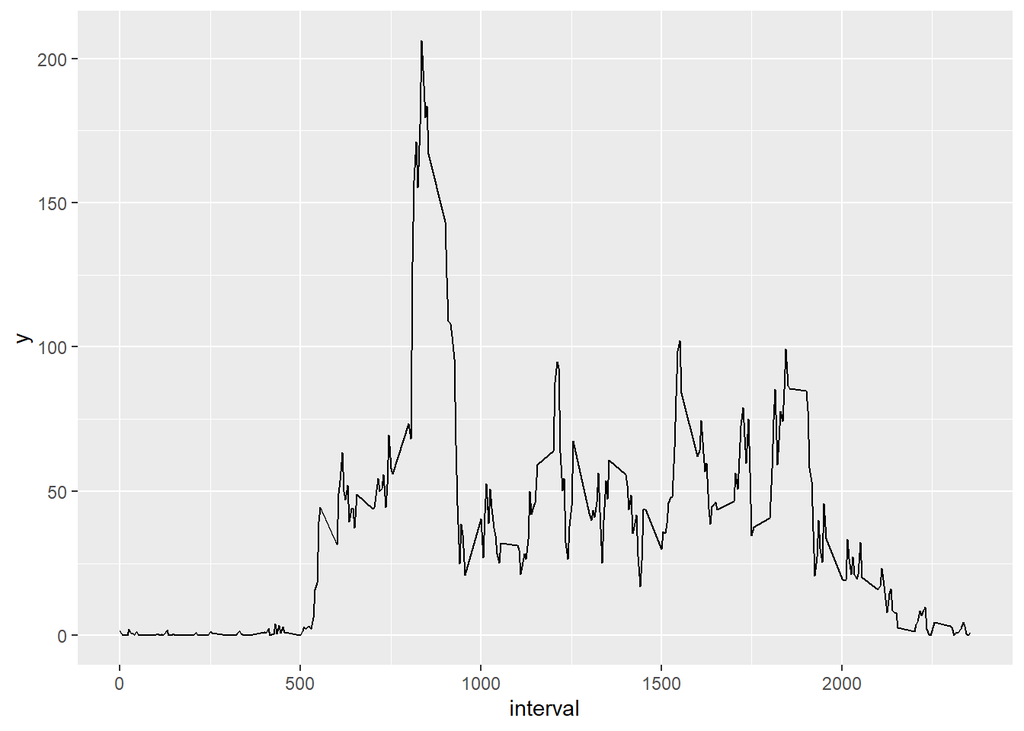

Which 5-minute interval, on average across all the days in the dataset, contains the maximum number of steps?

```r
max_interval <- interval_steps[which.max(interval_steps$nbr_steps),]
print("Maximum interval")
```

```
## [1] "Maximum interval"
```

```r
max_interval$interval
```

```
## [1] 835
```

P1_4 Note that there are a number of days/intervals where there are missing values (coded as NA). The presence of missing days may introduce bias into some calculations or summaries of the data. Calculate and report the total number of missing values in the dataset

```r
na_nbr <- sum(is.na(csv_data$steps))
print("Number of missing values is:")
```

```
## [1] "Number of missing values is:"
```

```r
na_nbr
```

```
## [1] 2304
```

Devise a strategy for filling in all of the missing values in the dataset. The strategy does not need to be sophisticated. For example, you could use the mean/median for that day, or the mean for that 5-minute interval, etc. Create a new dataset that is equal to the original dataset but with the missing data filled in.

```r
library(tidyverse)
new_df <- csv_data %>% group_by(interval) %>% mutate(steps=ifelse(is.na(steps), mean(steps, na.rm=T), steps))
head(new_df)
```

```
## # A tibble: 6 x 3
## # Groups:   interval [6]
##    steps date       interval
##    <dbl> <date>        <int>
## 1 1.72   2012-10-01        0
## 2 0.340  2012-10-01        5
## 3 0.132  2012-10-01       10
## 4 0.151  2012-10-01       15
## 5 0.0755 2012-10-01       20
## 6 2.09   2012-10-01       25
```

Make a histogram of the total number of steps taken each day

```
##         date nbr_steps_new
## 1 2012-10-01      10766.19
## 2 2012-10-02        126.00
## 3 2012-10-03      11352.00
## 4 2012-10-04      12116.00
## 5 2012-10-05      13294.00
## 6 2012-10-06      15420.00
```

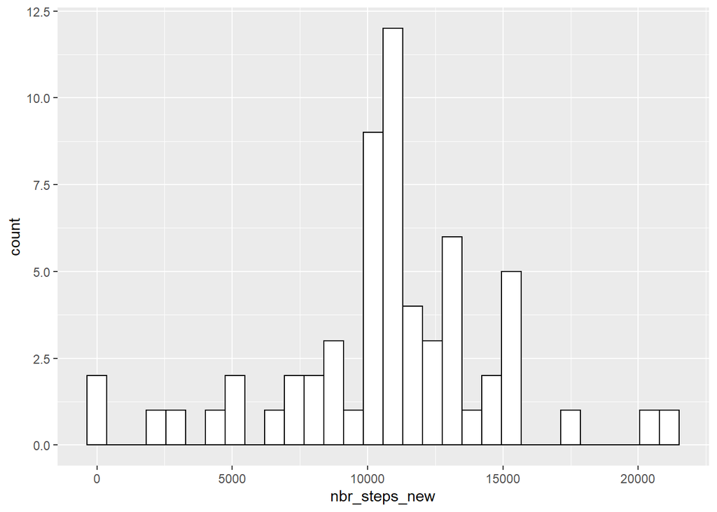

```r
my_mean_new <- mean(sum_steps_new$nbr_steps_new, na.rm = TRUE)
my_median_new <- median(sum_steps_new$nbr_steps_new, na.rm = TRUE)
my_mean_new
```

```
## [1] 10766.19
```

```r
my_median_new
```

```
## [1] 10766.19
```

P1_5 Are there differences in activity patterns between weekdays and weekends? For this part the weekdays() function may be of some help here. Use the dataset with the filled-in missing values for this part. Create a new factor variable in the dataset with two levels – “weekday” and “weekend” indicating whether a given date is a weekday or weekend day.

```r
library("ggplot2")
library("gridExtra")
new_df$week <- ifelse(weekdays(new_df$date) %in% c("Saturday", "Sunday"), "weekend", "weekday")
```

Make a panel plot containing a time series plot (i.e. type = “l”) of the 5-minute interval (x-axis) and the average number of steps taken, averaged across all weekday days or weekend days (y-axis). subset “weekday” and “weekend”

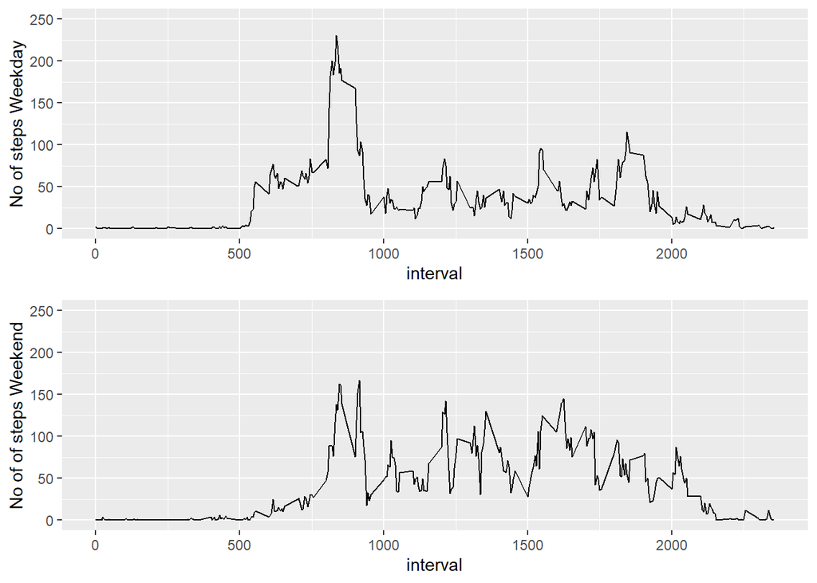